# Chapter-8-Lab

[Bruce Hartman](https://drbrucehartman.net/brucewebsite/)

Last updated: 20 January, 2025

# Introduction

Chapter 8 Lab from the HEADS text. The best use is to read in conjunction with the lab in Section 8.4.

# Packages

Regular R packages:

```r
library(tidyverse)
library(ggfortify)
library(GGally)
library(broom)
library(skimr)
library(gt)
library(patchwork)
library(yardstick)
library(car)
```

Github packages:

```r
library(devtools)
install_github("bhartman2/mbadtools")
library(mbadtools)
```

To install this package: use uncommented in your notebook.

```r
# install_github("bhartman2/HEADS")
# library(HEADS)
```

# Chapter 8 Lab (8.4)

Data:

```r
heartdisease %>% glimpse
```

```
Rows: 918
Columns: 10
$ Age              <dbl> 40, 49, 37, 48, 54, 39, 45, 54, 37, 48, 37, 58, 39, 49,…
$ Sex              <chr> "M", "F", "M", "F", "M", "M", "F", "M", "M", "F", "F", …
$ RestingBP        <dbl> 140, 160, 130, 138, 150, 120, 130, 110, 140, 120, 130, …
$ Cholesterol      <dbl> 289, 180, 283, 214, 195, 339, 237, 208, 207, 284, 211, …
$ FastingBS        <dbl> 0, 0, 0, 0, 0, 0, 0, 0, 0, 0, 0, 0, 0, 0, 0, 0, 0, 0, 0…
$ RestingECG       <chr> "Normal", "Normal", "ST", "Normal", "Normal", "Normal",…
$ MaxHR            <dbl> 172, 156, 98, 108, 122, 170, 170, 142, 130, 120, 142, 9…
$ Angina           <chr> "N", "N", "N", "Y", "N", "N", "N", "N", "Y", "N", "N", …
$ HeartPeakReading <dbl> 0.0, 1.0, 0.0, 1.5, 0.0, 0.0, 0.0, 0.0, 1.5, 0.0, 0.0, …
$ HeartDisease     <dbl> 0, 1, 0, 1, 0, 0, 0, 0, 1, 0, 0, 1, 0, 1, 0, 0, 1, 0, 1…
```

Wrangling:

```r
#convert some variables to factors
heartdisease$Sex <- as.factor(heartdisease$Sex)
heartdisease$FastingBS <- as.factor(heartdisease$FastingBS)
heartdisease$RestingECG <- as.factor(heartdisease$RestingECG)
heartdisease$Angina <- as.factor(heartdisease$Angina)
heartdisease$HeartDisease <- as.factor(heartdisease$HeartDisease)
summary(heartdisease)
```

```
      Age        Sex       RestingBP      Cholesterol    FastingBS  RestingECG
 Min.   :28.00   F:193   Min.   :  0.0   Min.   :  0.0   0:704     LVH   :188
 1st Qu.:47.00   M:725   1st Qu.:120.0   1st Qu.:173.2   1:214     Normal:552
 Median :54.00           Median :130.0   Median :223.0             ST    :178
 Mean   :53.51           Mean   :132.4   Mean   :198.8
 3rd Qu.:60.00           3rd Qu.:140.0   3rd Qu.:267.0
 Max.   :77.00           Max.   :200.0   Max.   :603.0
     MaxHR       Angina  HeartPeakReading  HeartDisease
 Min.   : 60.0   N:547   Min.   :-2.6000   0:410
 1st Qu.:120.0   Y:371   1st Qu.: 0.0000   1:508
 Median :138.0           Median : 0.6000
 Mean   :136.8           Mean   : 0.8874
 3rd Qu.:156.0           3rd Qu.: 1.5000
 Max.   :202.0           Max.   : 6.2000
```

Validation split:

```r
train <- heartdisease[1:700,]
test <- heartdisease[701:918,]
```

## Classification Tree (8.4.1)

Packages:

```r
library(rpart)
library(rpart.plot)
```

Model:

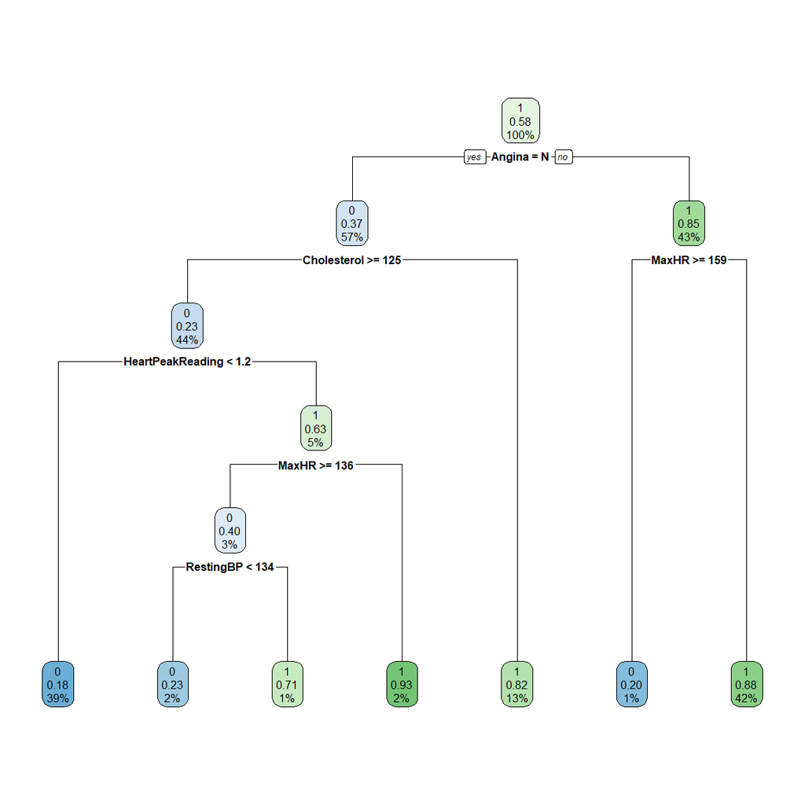

```r
cart <- rpart(formula = HeartDisease~., data = train, method = "class")
rpart.plot(cart)
```

For example, we build a classification tree that has a maximum depth of 5 and a minimum number of 50 patients in each terminal node and we split at each decision when there are at least 30 patients. We have λ = 0.01. The code is as follows:

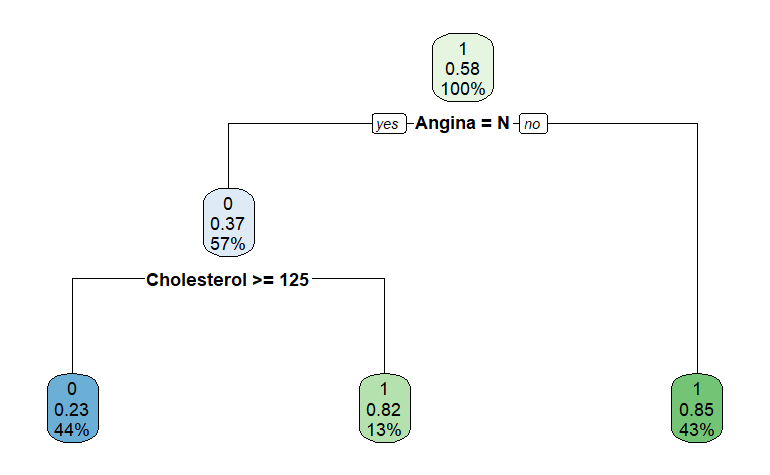

```r
cart2 <- rpart(formula = HeartDisease~., data = train, method = "class",
    minsplit = 30, minbucket = 50, maxdepth = 5, cp = 0.01)
rpart.plot(cart2)
```

We have the other option to use information gain to split the node. The code for a simple classification tree is as follows:

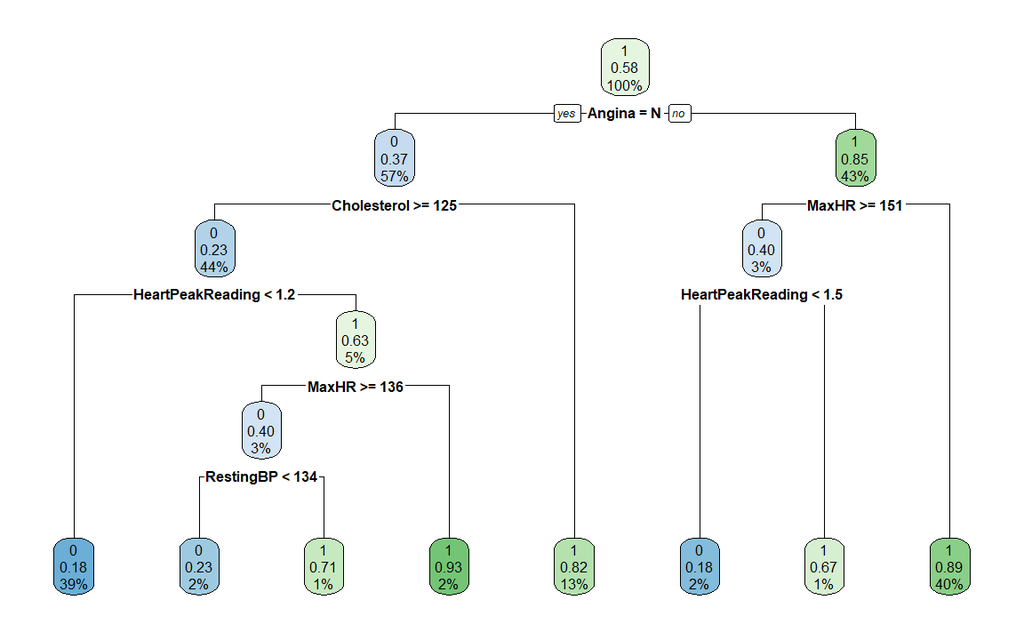

```r
cart3 <- rpart(formula = HeartDisease~., data = train,
              method = "class", parms = list(split = 'information'))
rpart.plot(cart3)
```

Predict on a patient:

```r
predict(cart, train[1,], "prob")
```

```
          0         1
1 0.8191882 0.1808118
```

AUC and ROC:

```r
library(pROC)
#calculate prediction on test and compute ROC
pred1 <- predict(cart, test, "prob")[,2]
roc(test$HeartDisease, pred1)
```

```
Call:
roc.default(response = test$HeartDisease, predictor = pred1)

Data: pred1 in 115 controls (test$HeartDisease 0) < 103 cases (test$HeartDisease 1).
Area under the curve: 0.7629
```

```r
pred2 <- predict(cart2, test, "prob")[,2]
roc(test$HeartDisease, pred2)
```

```
Call:
roc.default(response = test$HeartDisease, predictor = pred2)

Data: pred2 in 115 controls (test$HeartDisease 0) < 103 cases (test$HeartDisease 1).
Area under the curve: 0.7289
```

```r
pred3 <- predict(cart3, test, "prob")[,2]
roc(test$HeartDisease, pred3)
```

```
Call:
roc.default(response = test$HeartDisease, predictor = pred3)

Data: pred3 in 115 controls (test$HeartDisease 0) < 103 cases (test$HeartDisease 1).
Area under the curve: 0.7735
```

`pred3` has the highest AUC so is the preferred model.

## Bagging (8.4.2)

We import the `ipred` library to perform bagging in R. Because bagging is an ensemble of classification trees, we use the function `bagging()` in conjunction with the functions in the `rpart` library. In order to specify parameters for the classification tree, we use `rpart.control`. Suppose we want to use the same setting as cart2. Then, with 100 classification trees, we do the following:

```r
library(ipred)
bag <- bagging(formula = HeartDisease~., data = train, nbagg=100,
               control = rpart.control(minsplit = 30,
                                       minbucket = 50,
                                       maxdepth = 5,
                                       cp = 0.01))
bag_pred <- predict(bag, test, "prob")[,2]
roc(test$HeartDisease, bag_pred)
```

```
Call:
roc.default(response = test$HeartDisease, predictor = bag_pred)

Data: bag_pred in 115 controls (test$HeartDisease 0) < 103 cases (test$HeartDisease 1).
Area under the curve: 0.827
```

By using bagging, we significantly improve the AUC, which conveys how using multiple classification trees altogether can have better predictive performance than just one tree.

## Random forest (8.4.3)

WE set the number of trees to 300.

```r
library(randomForest)
rf <- randomForest(formula = HeartDisease~., data = train, ntree = 300)
rf_pred <- predict(rf, test, "prob")[,2]
roc(test$HeartDisease, rf_pred)
```

```
Call:
roc.default(response = test$HeartDisease, predictor = rf_pred)

Data: rf_pred in 115 controls (test$HeartDisease 0) < 103 cases (test$HeartDisease 1).
Area under the curve: 0.8177
```

We observe that the random forest generally yields a higher AUC than bagging. But here it does not. As with bagging it involves random choice of trees and therefore will not be the same each time.

## SVM (8.4.4)

To use SVM for binary classification in R, we use the function `ksvm()` from the library `kernlab`.

```r
library(kernlab)
ksvm_fit <- ksvm(HeartDisease~., data = train, prob.model=TRUE)
ksvm_pred <- predict(ksvm_fit, test, "probabilities")[,2]
roc(test$HeartDisease, ksvm_pred)
```

```
Call:
roc.default(response = test$HeartDisease, predictor = ksvm_pred)

Data: ksvm_pred in 115 controls (test$HeartDisease 0) < 103 cases (test$HeartDisease 1).
Area under the curve: 0.8604
```

Here we fitted a soft-margin SVM model with the default Gaussian kernel and penalty parameter c = 1 onto the `heartdisease` training set. Note that we need to specify “TRUE” for the argument prob.model so that we obtain a probability value for each classification when using the predict function.

To increase the penalty parameter c for soft-margin SVM, we specify in the argument C. As an example, we apply soft-margin SVM with c = 10.

```r
ksvm_fit2 <- ksvm(HeartDisease~., data = train, prob.model=TRUE, C=10)
ksvm_pred2 <- predict(ksvm_fit2, test, "probabilities")[,2]
roc(test$HeartDisease, ksvm_pred2)
```

```
Call:
roc.default(response = test$HeartDisease, predictor = ksvm_pred2)

Data: ksvm_pred2 in 115 controls (test$HeartDisease 0) < 103 cases (test$HeartDisease 1).
Area under the curve: 0.8008
```

We can use different kernels. To specify the parameters for each kernel, we pass a list of hyperparameters through the argument `kpar`. For example, we apply an SVM model with polynomial kernel that has degree 2, scale 5, and offset 1.

```r
ksvm_fit3 <- ksvm(HeartDisease~., data = train, prob.model=TRUE, kernel = 'polydot',
kpar = list(degree=2, scale = 5, offset=1))
ksvm_pred3 <- predict(ksvm_fit3, test, "probabilities")[,2]
roc(test$HeartDisease, ksvm_pred3)
```

```
Call:
roc.default(response = test$HeartDisease, predictor = ksvm_pred3)

Data: ksvm_pred3 in 115 controls (test$HeartDisease 0) < 103 cases (test$HeartDisease 1).
Area under the curve: 0.8211
```

For this model, we again obtain a reasonably high AUC for a model that classifies patients with heart diseases.

# References

Mehrotra, Sanjay, Kevin Bui, and Hari Balasubramanian (2024). Healthcare Engineering, Analytics, and Decision Sciences: An Introduction. December 11, 2024. (https://sites.google.com/view/healthcareengineering/) Chapter 8.